# Introduction to R

05.12.2019

## So you want to learn R…

[figure not shown]

- Data analysis
- Statistics
- Scripting
- Machine learning
- Publication-grade figures
- Web application
- I was told I should

## So many languages

- There are more than 200 programming languages
- The tiobe index keeps track of popularity: https://tiobe.com/tiobe-index/

[figure not shown]

## Language choice depends on purpose

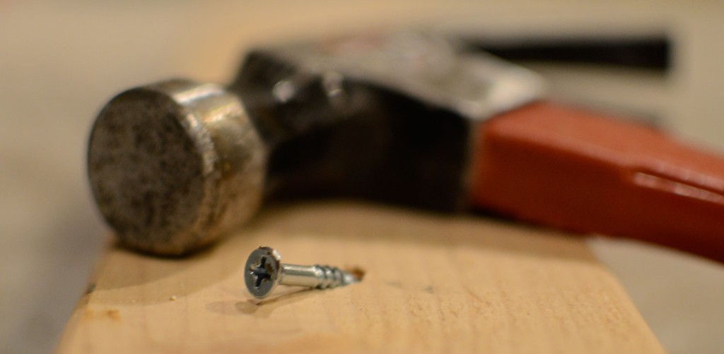

## Python, R’s closest competition

[figure not shown]

## R, more than a language

- Incredibly rich ecosystem
- Strong community
- Industry support
- #1 for bioinformatics

[figure not shown]

## CRAN

[figure not shown]

## Are all of them useful for you?

```r
library(cowsay)
cat(say("R is the best", by = "hypnotoad", type = "string"))
```

```````
##
##
##  -----
## R is the best
##  ------
##     \          ,'``.._   ,'``.
##      \        :,--._:)\,:,._,.:
##       \       :`--,''   :`...';\
##                `,'       `---'  `.
##                /                 :
##               /                   \
##             ,'                     :\.___,-.
##            `...,---'``````-..._    |:       \
##              (                 )   ;:    )   \  _,-.
##               `.              (   //          `'    \
##                :               `.//  )      )     , ;
##              ,-|`.            _,'/       )    ) ,' ,'
##             (  :`.`-..____..=:.-':     .     _,' ,'
##              `,'\ ``--....-)='    `._,  \  ,') _ '``._
##           _.-/ _ `.       (_)      /     )' ; / \ \`-.'
##          `--(   `-:`.     `' ___..'  _,-'   |/   `.)
##              `-. `.`.``-----``--,  .'
##                |/`.\`'        ,','); SSt
##                    `         (/  (/
##
```````

## Bioconductor

[figure not shown]

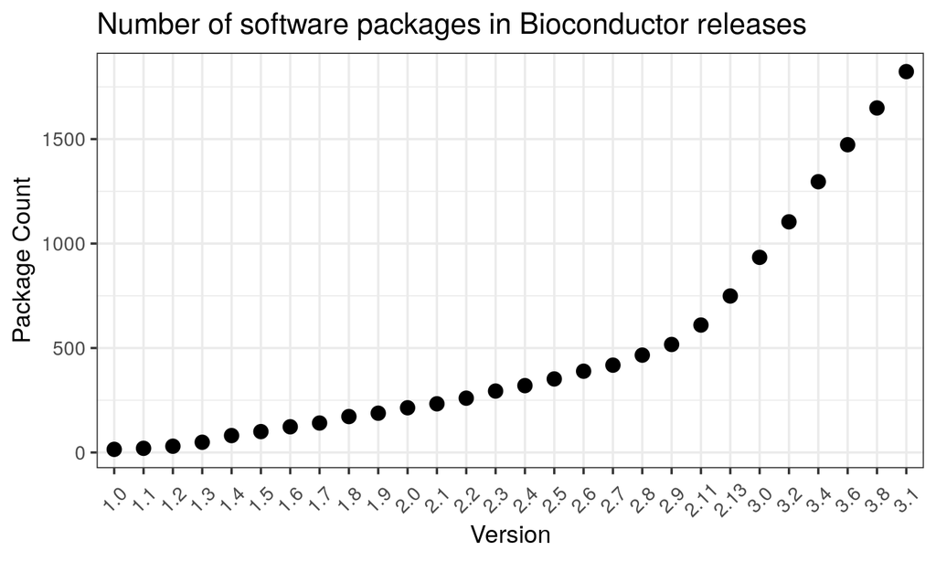

## Why some people don’t like R

- flexibility comes at a cost
- overwhelming choice
- dozens of ways for solving a task
- easy to write bad and inefficient code
- mixing work-flows, inconsistencies
- not a clean language

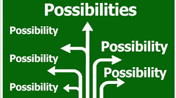

## Agenda

- 08.30 - 09.00 Introduction
- 09.00 - 10.00 R data handling basics - tidyverse, bioconductor
- 10.00 - 10.15 Coffee break
- 10.15 - 12.00 Writing your own R package
- 12.00 - 13.00 Lunch break
- 13.00 - 14.45 Epigenomic data analysis with DeepBlueR
- 14.45 - 15.00 Coffee break
- 15.00 - 16.30 Interactive web application with R shiny
- 16.30 - 17.00 Wrap-up and discussion

## Learning Goals

- Get familiar with basic concepts in R
- Learn how to get help
- Learn what is possible
- Learn how R can be useful for your research
- Play and loose fear

[figure not shown]

## Parallelization

- speedup for long computations
- many ways
  - parallel, snow, multicore, …
  - foreach supports various mechanisms via %dopar%
  - mcapply
  - BiocParallel
  - …

## Cloud computing

- with R you can submit a long-running analysis as a job to a server
- e.g. slurm, sun grid engine, …

## Simple data types in R

- number: integer, float
- character: strings, texts
- factor: categories
- logical: TRUE / FALSE

```r
an_int <- 5
a_vector_with_ints <- c(1, 2, 3, 4, 5)
a_vector_with_ints <- seq(1, 5, by = 1)

a_float <- 0.1
a_vector_with_floats <- c(0.1, 0.2, 0.3, 0.4, 0.5)
a_vector_with_floats <- seq(0.1, 0.5, by = 0.1)

a_string <- "R is great"
a_vector_of_strings <- c(a_string, ", isnt't it?")
cat(paste0(a_vector_of_strings, collapse = ""))
```

```
## R is great, isnt't it?
```

## Be careful with factors

```r
a_vector <- c("disease", "disease", "control", "control")
a_factor <- as.factor(a_vector)
a_factor
```

```
## [1] disease disease control control
## Levels: control disease
```

```r
another_vector <- c(1,0,1,0)
another_factor <- as.factor(another_vector)
as.integer(another_factor)
```

```
## [1] 2 1 2 1
```

```r
as.integer(as.character(another_factor))
```

```
## [1] 1 0 1 0
```

## Data structures in R

Tables:

- data.frame: many vectors make a table
- matrix: every element has the same type

More efficient implementations of tables:

- tibble (tidyverse)
- data.table (data.table)

## Data structures in R contd

Lists:

- not the same as a vector, can contain anything
- lists of lists
- lists of data.frame
- list of objects (e.g. Bioconductor ExpressionSet)
- …

## Functions

- have a name
- take any number of (named) input parameters
- return one output of any type

```r
add_to_five <- function(add_me){
  return(5 + add_me)
}
```

## Final proof that R is crazy

```r
#DON'T EVER DO THIS
'+' <- function(a, b){
  return(a - b)
}

5 + 4
```

```
## [1] 1
```

```r
rm('+') #clean up
```

## Passthrough

Functions can pass input they don’t need

```r
add <- function(a, b){ a + b }

add_to_five <- function(...) add(5, ...)

add_to_five(7)
```

```
## [1] 12
```

## Missing values - NA

```r
a <- c(5, 6, 9, 1, NA, 5)

mean(a) #wrong
```

```
## [1] NA
```

```r
mean(na.omit(a)) #better
```

```
## [1] 5.2
```

```r
mean(a, na.rm = TRUE) #best
```

```
## [1] 5.2
```

## Special numbers

```r
4/0
```

```
## [1] Inf
```

```r
0/0
```

```
## [1] NaN
```

```r
log2(0)
```

```
## [1] -Inf
```

## if clauses

```r
R_is_great <- TRUE
if(R_is_great)
{
  cat("I know!")
} else {
  cat("Liar!")
}
```

```
## I know!
```

## Loops

```r
for(i in 1:10) cat("R is great!")
```

```
## R is great!R is great!R is great!R is great!R is great!R is great!R is great!R is great!R is great!R is great!
```

```r
for(i in seq_len(10)) cat("this is better")
```

```
## this is betterthis is betterthis is betterthis is betterthis is betterthis is betterthis is betterthis is betterthis is betterthis is better
```

```r
for(i in c("stupid", "okay", "great")) cat("R is", i, "!")
```

```
## R is stupid !R is okay !R is great !
```

## Apply

- lapply over lists
- apply(x, margin) where x is a matrix,
- margin is either 1 for rows or 2 for columns

```r
lapply(list("ok", "horrible", "great"), function(x) return(paste("R is", x, "!")))
```

```
## [[1]]
## [1] "R is ok !"
##
## [[2]]
## [1] "R is horrible !"
##
## [[3]]
## [1] "R is great !"
```

```r
cars
```

```
##    speed dist
## 1      4    2
## 2      4   10
## 3      7    4
## 4      7   22
## 5      8   16
## 6      9   10
## 7     10   18
## 8     10   26
## 9     10   34
## 10    11   17
## 11    11   28
## 12    12   14
## 13    12   20
## 14    12   24
```

[output cut: 36 more lines]

```r
cars_matrix <- as.matrix(cars)

apply(cars_matrix, 1, function(x){ x[1] * x[2]})
```

```
##  [1]    8   40   28  154  128   90  180  260  340  187  308  168  240  288
## [15]  336  338  442  442  598  364  504  840 1120  300  390  810  512  640
## [29]  544  680  850  756 1008 1368 1512  684  874 1292  640  960 1040 1120
## [43] 1280 1452 1242 1680 2208 2232 2880 2125
```

```r
apply(cars_matrix, 2, sum)
```

```
## speed  dist
##   770  2149
```

## Foreach

A powerful loop implementation

```r
library(foreach)
foreach(i = 1:2) %do% { i * 2 }
```

```
## [[1]]
## [1] 2
##
## [[2]]
## [1] 4
```

```r
foreach(i = 1:10, .combine = sum) %do% {  i }
```

```
## [1] 55
```